# Risk Factor Analysis

## Outcome Variable

**Outcome Variable:** haz

## Predictor Variables

**Intervention Variable:** fhtcm

**Adjustment Set:**

- arm
- W_mage
- W_fage
- meducyrs
- feducyrs
- W_mhtcm
- W_mwtkg
- W_mbmi
- single
- delta_W_mage
- delta_W_fage
- delta_meducyrs
- delta_feducyrs
- delta_W_mhtcm
- delta_W_mwtkg
- delta_W_mbmi
- delta_single

## Stratifying Variables

The analysis was stratified on these variable(s):

- agecat
- studyid
- country

## Data Summary

| agecat | studyid | country | fhtcm | n_cell | n | outcome_variable |
| --- | --- | --- | --- | --- | --- | --- |
| Birth | COHORTS | GUATEMALA | >=167 cm | 29 | 206 | haz |
| Birth | COHORTS | GUATEMALA | <162 cm | 121 | 206 | haz |
| Birth | COHORTS | GUATEMALA | [162-167) cm | 56 | 206 | haz |
| Birth | Keneba | GAMBIA | >=167 cm | 772 | 1167 | haz |
| Birth | Keneba | GAMBIA | <162 cm | 87 | 1167 | haz |
| Birth | Keneba | GAMBIA | [162-167) cm | 308 | 1167 | haz |
| Birth | PROBIT | BELARUS | >=167 cm | 11742 | 12535 | haz |
| Birth | PROBIT | BELARUS | <162 cm | 168 | 12535 | haz |
| Birth | PROBIT | BELARUS | [162-167) cm | 625 | 12535 | haz |
| Birth | SAS-CompFeed | INDIA | >=167 cm | 343 | 746 | haz |
| Birth | SAS-CompFeed | INDIA | <162 cm | 190 | 746 | haz |
| Birth | SAS-CompFeed | INDIA | [162-167) cm | 213 | 746 | haz |
| 6 months | COHORTS | GUATEMALA | >=167 cm | 45 | 336 | haz |
| 6 months | COHORTS | GUATEMALA | <162 cm | 197 | 336 | haz |
| 6 months | COHORTS | GUATEMALA | [162-167) cm | 94 | 336 | haz |
| 6 months | Keneba | GAMBIA | >=167 cm | 979 | 1511 | haz |
| 6 months | Keneba | GAMBIA | <162 cm | 113 | 1511 | haz |
| 6 months | Keneba | GAMBIA | [162-167) cm | 419 | 1511 | haz |
| 6 months | PROBIT | BELARUS | >=167 cm | 11146 | 11894 | haz |
| 6 months | PROBIT | BELARUS | <162 cm | 156 | 11894 | haz |
| 6 months | PROBIT | BELARUS | [162-167) cm | 592 | 11894 | haz |
| 6 months | SAS-CompFeed | INDIA | >=167 cm | 369 | 807 | haz |
| 6 months | SAS-CompFeed | INDIA | <162 cm | 194 | 807 | haz |
| 6 months | SAS-CompFeed | INDIA | [162-167) cm | 244 | 807 | haz |
| 6 months | SAS-FoodSuppl | INDIA | >=167 cm | 102 | 372 | haz |
| 6 months | SAS-FoodSuppl | INDIA | <162 cm | 148 | 372 | haz |
| 6 months | SAS-FoodSuppl | INDIA | [162-167) cm | 122 | 372 | haz |
| 24 months | COHORTS | GUATEMALA | >=167 cm | 70 | 526 | haz |
| 24 months | COHORTS | GUATEMALA | <162 cm | 307 | 526 | haz |
| 24 months | COHORTS | GUATEMALA | [162-167) cm | 149 | 526 | haz |
| 24 months | Keneba | GAMBIA | >=167 cm | 821 | 1297 | haz |
| 24 months | Keneba | GAMBIA | <162 cm | 97 | 1297 | haz |
| 24 months | Keneba | GAMBIA | [162-167) cm | 379 | 1297 | haz |
| 24 months | PROBIT | BELARUS | >=167 cm | 3445 | 3670 | haz |
| 24 months | PROBIT | BELARUS | <162 cm | 53 | 3670 | haz |
| 24 months | PROBIT | BELARUS | [162-167) cm | 172 | 3670 | haz |

The following strata were considered:

- agecat: 24 months, studyid: COHORTS, country: GUATEMALA
- agecat: 24 months, studyid: Keneba, country: GAMBIA
- agecat: 24 months, studyid: PROBIT, country: BELARUS
- agecat: 6 months, studyid: COHORTS, country: GUATEMALA
- agecat: 6 months, studyid: Keneba, country: GAMBIA
- agecat: 6 months, studyid: PROBIT, country: BELARUS
- agecat: 6 months, studyid: SAS-CompFeed, country: INDIA
- agecat: 6 months, studyid: SAS-FoodSuppl, country: INDIA
- agecat: Birth, studyid: COHORTS, country: GUATEMALA
- agecat: Birth, studyid: Keneba, country: GAMBIA
- agecat: Birth, studyid: PROBIT, country: BELARUS
- agecat: Birth, studyid: SAS-CompFeed, country: INDIA

## Methods Detail

We’re interested in the causal parameters $E[Y_a]$ for all values of $a \in \mathcal{A}$. These parameters represent the mean outcome if, possibly contrary to fact, we intervened to set all units to have $A=a$. Under the randomization and positivity assumptions, these are identified by the statistical parameters $\psi_a=E_W[E_{Y|A,W}(Y|A=a,W)]$. In addition, we’re interested in the mean of $Y$, $E[Y]$ under no intervention (the observed mean). We will estimate these parameters by using SuperLearner to fit the relevant likelihood factors – $E_{Y|A,W}(Y|A=a,W)$ and $p(A=a|W)$, and then updating our likelihood fit using a joint TMLE.

For unadjusted analyses ($W=\{\}$), initial likelihoods were estimated using Lrnr_glm to estimate the simple $E(Y|A)$ and Lrnr_mean to estimate $p(A)$. For adjusted analyses, a small library containing Lrnr_glmnet, Lrnr_xgboost, and Lrnr_mean was used.

Having estimated these parameters, we will then use the delta method to estimate relative risks and attributable risks relative to a prespecified baseline level of $A$.

# Results Detail

## Results Plots

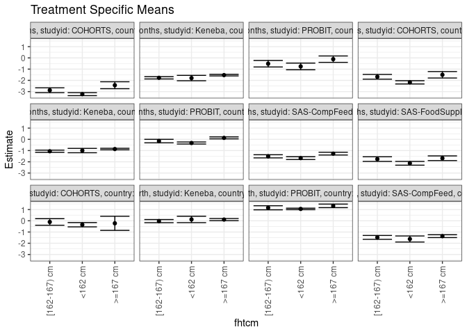

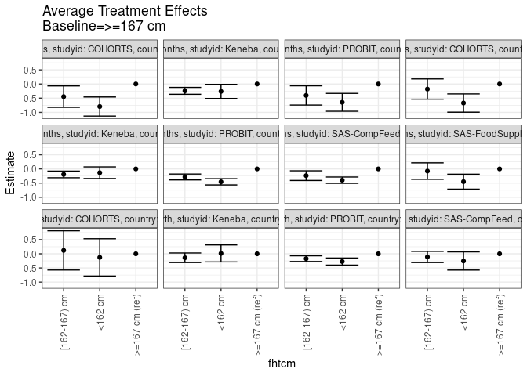

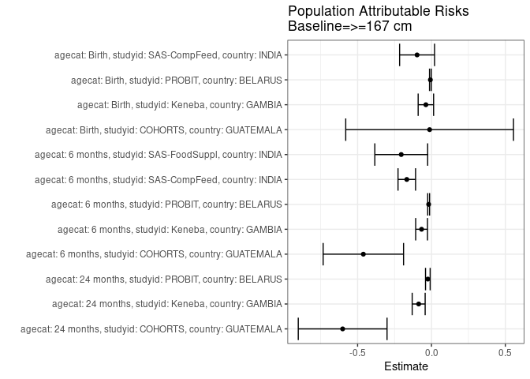

## Results Table

### Parameter: TSM

| agecat | studyid | country | intervention_level | baseline_level | estimate | ci_lower | ci_upper |
| --- | --- | --- | --- | --- | --- | --- | --- |
| Birth | COHORTS | GUATEMALA | >=167 cm | NA | -0.2240936 | -0.8529014 | 0.4047142 |
| Birth | COHORTS | GUATEMALA | <162 cm | NA | -0.3503786 | -0.5419722 | -0.1587850 |
| Birth | COHORTS | GUATEMALA | [162-167) cm | NA | -0.1044806 | -0.3968507 | 0.1878896 |
| Birth | Keneba | GAMBIA | >=167 cm | NA | 0.1080697 | 0.0136663 | 0.2024730 |
| Birth | Keneba | GAMBIA | <162 cm | NA | 0.1210679 | -0.1647022 | 0.4068380 |
| Birth | Keneba | GAMBIA | [162-167) cm | NA | -0.0309025 | -0.1706765 | 0.1088715 |
| Birth | PROBIT | BELARUS | >=167 cm | NA | 1.3277541 | 1.1702677 | 1.4852404 |
| Birth | PROBIT | BELARUS | <162 cm | NA | 1.0548133 | 0.9886460 | 1.1209805 |
| Birth | PROBIT | BELARUS | [162-167) cm | NA | 1.1565079 | 0.9764813 | 1.3365345 |
| Birth | SAS-CompFeed | INDIA | >=167 cm | NA | -1.3676281 | -1.4938315 | -1.2414247 |
| Birth | SAS-CompFeed | INDIA | <162 cm | NA | -1.6209807 | -1.8924964 | -1.3494649 |
| Birth | SAS-CompFeed | INDIA | [162-167) cm | NA | -1.4779362 | -1.6514060 | -1.3044664 |
| 6 months | COHORTS | GUATEMALA | >=167 cm | NA | -1.5041247 | -1.7907176 | -1.2175318 |
| 6 months | COHORTS | GUATEMALA | <162 cm | NA | -2.1762963 | -2.3206687 | -2.0319239 |
| 6 months | COHORTS | GUATEMALA | [162-167) cm | NA | -1.6827303 | -1.8937446 | -1.4717159 |
| 6 months | Keneba | GAMBIA | >=167 cm | NA | -0.8651551 | -0.9334176 | -0.7968926 |
| 6 months | Keneba | GAMBIA | <162 cm | NA | -0.9993080 | -1.1937969 | -0.8048192 |
| 6 months | Keneba | GAMBIA | [162-167) cm | NA | -1.0598111 | -1.1580664 | -0.9615558 |
| 6 months | PROBIT | BELARUS | >=167 cm | NA | 0.1298947 | 0.0424109 | 0.2173785 |
| 6 months | PROBIT | BELARUS | <162 cm | NA | -0.3255871 | -0.4162948 | -0.2348794 |
| 6 months | PROBIT | BELARUS | [162-167) cm | NA | -0.1544374 | -0.3092797 | 0.0004050 |
| 6 months | SAS-CompFeed | INDIA | >=167 cm | NA | -1.2730117 | -1.3959179 | -1.1501056 |
| 6 months | SAS-CompFeed | INDIA | <162 cm | NA | -1.6705726 | -1.7955221 | -1.5456231 |
| 6 months | SAS-CompFeed | INDIA | [162-167) cm | NA | -1.5105979 | -1.6499018 | -1.3712939 |
| 6 months | SAS-FoodSuppl | INDIA | >=167 cm | NA | -1.6824818 | -1.8895458 | -1.4754179 |
| 6 months | SAS-FoodSuppl | INDIA | <162 cm | NA | -2.1323755 | -2.2987674 | -1.9659836 |
| 6 months | SAS-FoodSuppl | INDIA | [162-167) cm | NA | -1.7583250 | -1.9645407 | -1.5521093 |
| 24 months | COHORTS | GUATEMALA | >=167 cm | NA | -2.4334990 | -2.7423472 | -2.1246508 |
| 24 months | COHORTS | GUATEMALA | <162 cm | NA | -3.2282810 | -3.3608259 | -3.0957360 |
| 24 months | COHORTS | GUATEMALA | [162-167) cm | NA | -2.8792147 | -3.0965792 | -2.6618502 |
| 24 months | Keneba | GAMBIA | >=167 cm | NA | -1.5334193 | -1.6040401 | -1.4627984 |
| 24 months | Keneba | GAMBIA | <162 cm | NA | -1.7945460 | -2.0339278 | -1.5551643 |
| 24 months | Keneba | GAMBIA | [162-167) cm | NA | -1.7746595 | -1.8758179 | -1.6735010 |
| 24 months | PROBIT | BELARUS | >=167 cm | NA | -0.1144433 | -0.3993328 | 0.1704462 |
| 24 months | PROBIT | BELARUS | <162 cm | NA | -0.7607714 | -1.0584086 | -0.4631342 |
| 24 months | PROBIT | BELARUS | [162-167) cm | NA | -0.5177551 | -0.8083040 | -0.2272062 |

### Parameter: E(Y)

| agecat | studyid | country | intervention_level | baseline_level | estimate | ci_lower | ci_upper |
| --- | --- | --- | --- | --- | --- | --- | --- |
| Birth | COHORTS | GUATEMALA | NA | NA | -0.2367476 | -0.3941046 | -0.0793906 |
| Birth | Keneba | GAMBIA | NA | NA | 0.0702057 | -0.0035933 | 0.1440046 |
| Birth | PROBIT | BELARUS | NA | NA | 1.3203658 | 1.1636745 | 1.4770571 |
| Birth | SAS-CompFeed | INDIA | NA | NA | -1.4650804 | -1.5752607 | -1.3549001 |
| 6 months | COHORTS | GUATEMALA | NA | NA | -1.9652976 | -2.0794998 | -1.8510954 |
| 6 months | Keneba | GAMBIA | NA | NA | -0.9321551 | -0.9872314 | -0.8770788 |
| 6 months | PROBIT | BELARUS | NA | NA | 0.1108245 | 0.0214240 | 0.2002250 |
| 6 months | SAS-CompFeed | INDIA | NA | NA | -1.4400743 | -1.5370187 | -1.3431300 |
| 6 months | SAS-FoodSuppl | INDIA | NA | NA | -1.8871505 | -1.9993302 | -1.7749709 |
| 24 months | COHORTS | GUATEMALA | NA | NA | -3.0347529 | -3.1289563 | -2.9405494 |
| 24 months | Keneba | GAMBIA | NA | NA | -1.6200950 | -1.6766111 | -1.5635788 |
| 24 months | PROBIT | BELARUS | NA | NA | -0.1390400 | -0.4237657 | 0.1456858 |

### Parameter: ATE

| agecat | studyid | country | intervention_level | baseline_level | estimate | ci_lower | ci_upper |
| --- | --- | --- | --- | --- | --- | --- | --- |
| Birth | COHORTS | GUATEMALA | >=167 cm | >=167 cm | 0.0000000 | 0.0000000 | 0.0000000 |
| Birth | COHORTS | GUATEMALA | <162 cm | >=167 cm | -0.1262850 | -0.7846770 | 0.5321070 |
| Birth | COHORTS | GUATEMALA | [162-167) cm | >=167 cm | 0.1196131 | -0.5737789 | 0.8130050 |
| Birth | Keneba | GAMBIA | >=167 cm | >=167 cm | 0.0000000 | 0.0000000 | 0.0000000 |
| Birth | Keneba | GAMBIA | <162 cm | >=167 cm | 0.0129982 | -0.2868019 | 0.3127984 |
| Birth | Keneba | GAMBIA | [162-167) cm | >=167 cm | -0.1389721 | -0.3072886 | 0.0293444 |
| Birth | PROBIT | BELARUS | >=167 cm | >=167 cm | 0.0000000 | 0.0000000 | 0.0000000 |
| Birth | PROBIT | BELARUS | <162 cm | >=167 cm | -0.2729408 | -0.3982891 | -0.1475925 |
| Birth | PROBIT | BELARUS | [162-167) cm | >=167 cm | -0.1712462 | -0.2720223 | -0.0704701 |
| Birth | SAS-CompFeed | INDIA | >=167 cm | >=167 cm | 0.0000000 | 0.0000000 | 0.0000000 |
| Birth | SAS-CompFeed | INDIA | <162 cm | >=167 cm | -0.2533526 | -0.5745833 | 0.0678780 |
| Birth | SAS-CompFeed | INDIA | [162-167) cm | >=167 cm | -0.1103082 | -0.3076911 | 0.0870748 |
| 6 months | COHORTS | GUATEMALA | >=167 cm | >=167 cm | 0.0000000 | 0.0000000 | 0.0000000 |
| 6 months | COHORTS | GUATEMALA | <162 cm | >=167 cm | -0.6721716 | -0.9941264 | -0.3502168 |
| 6 months | COHORTS | GUATEMALA | [162-167) cm | >=167 cm | -0.1786056 | -0.5363169 | 0.1791057 |
| 6 months | Keneba | GAMBIA | >=167 cm | >=167 cm | 0.0000000 | 0.0000000 | 0.0000000 |
| 6 months | Keneba | GAMBIA | <162 cm | >=167 cm | -0.1341529 | -0.3395497 | 0.0712439 |
| 6 months | Keneba | GAMBIA | [162-167) cm | >=167 cm | -0.1946560 | -0.3120863 | -0.0772256 |
| 6 months | PROBIT | BELARUS | >=167 cm | >=167 cm | 0.0000000 | 0.0000000 | 0.0000000 |
| 6 months | PROBIT | BELARUS | <162 cm | >=167 cm | -0.4554818 | -0.5649867 | -0.3459769 |
| 6 months | PROBIT | BELARUS | [162-167) cm | >=167 cm | -0.2843320 | -0.3878161 | -0.1808480 |
| 6 months | SAS-CompFeed | INDIA | >=167 cm | >=167 cm | 0.0000000 | 0.0000000 | 0.0000000 |
| 6 months | SAS-CompFeed | INDIA | <162 cm | >=167 cm | -0.3975609 | -0.5088281 | -0.2862937 |
| 6 months | SAS-CompFeed | INDIA | [162-167) cm | >=167 cm | -0.2375861 | -0.4085394 | -0.0666329 |
| 6 months | SAS-FoodSuppl | INDIA | >=167 cm | >=167 cm | 0.0000000 | 0.0000000 | 0.0000000 |
| 6 months | SAS-FoodSuppl | INDIA | <162 cm | >=167 cm | -0.4498937 | -0.7132672 | -0.1865201 |
| 6 months | SAS-FoodSuppl | INDIA | [162-167) cm | >=167 cm | -0.0758432 | -0.3662531 | 0.2145667 |
| 24 months | COHORTS | GUATEMALA | >=167 cm | >=167 cm | 0.0000000 | 0.0000000 | 0.0000000 |
| 24 months | COHORTS | GUATEMALA | <162 cm | >=167 cm | -0.7947819 | -1.1315988 | -0.4579651 |
| 24 months | COHORTS | GUATEMALA | [162-167) cm | >=167 cm | -0.4457157 | -0.8239406 | -0.0674907 |
| 24 months | Keneba | GAMBIA | >=167 cm | >=167 cm | 0.0000000 | 0.0000000 | 0.0000000 |
| 24 months | Keneba | GAMBIA | <162 cm | >=167 cm | -0.2611268 | -0.5100729 | -0.0121807 |
| 24 months | Keneba | GAMBIA | [162-167) cm | >=167 cm | -0.2412402 | -0.3627766 | -0.1197038 |
| 24 months | PROBIT | BELARUS | >=167 cm | >=167 cm | 0.0000000 | 0.0000000 | 0.0000000 |
| 24 months | PROBIT | BELARUS | <162 cm | >=167 cm | -0.6463281 | -0.9612205 | -0.3314357 |
| 24 months | PROBIT | BELARUS | [162-167) cm | >=167 cm | -0.4033118 | -0.7430183 | -0.0636052 |

### Parameter: PAR

| agecat | studyid | country | intervention_level | baseline_level | estimate | ci_lower | ci_upper |
| --- | --- | --- | --- | --- | --- | --- | --- |
| Birth | COHORTS | GUATEMALA | >=167 cm | NA | -0.0126539 | -0.5803618 | 0.5550539 |
| Birth | Keneba | GAMBIA | >=167 cm | NA | -0.0378640 | -0.0900811 | 0.0143531 |
| Birth | PROBIT | BELARUS | >=167 cm | NA | -0.0073883 | -0.0131781 | -0.0015985 |
| Birth | SAS-CompFeed | INDIA | >=167 cm | NA | -0.0974524 | -0.2157008 | 0.0207961 |
| 6 months | COHORTS | GUATEMALA | >=167 cm | NA | -0.4611729 | -0.7333912 | -0.1889547 |
| 6 months | Keneba | GAMBIA | >=167 cm | NA | -0.0670000 | -0.1069495 | -0.0270506 |
| 6 months | PROBIT | BELARUS | >=167 cm | NA | -0.0190702 | -0.0253988 | -0.0127416 |
| 6 months | SAS-CompFeed | INDIA | >=167 cm | NA | -0.1670626 | -0.2264267 | -0.1076985 |
| 6 months | SAS-FoodSuppl | INDIA | >=167 cm | NA | -0.2046687 | -0.3835355 | -0.0258019 |
| 24 months | COHORTS | GUATEMALA | >=167 cm | NA | -0.6012538 | -0.9016839 | -0.3008238 |
| 24 months | Keneba | GAMBIA | >=167 cm | NA | -0.0866757 | -0.1305573 | -0.0427941 |
| 24 months | PROBIT | BELARUS | >=167 cm | NA | -0.0245966 | -0.0402801 | -0.0089132 |